# Balancing validation snapshot

Compare stored R and Python Monte Carlo results with the right uncertainty measure.

Stored R and Python results provide a cross-language check for augmented balancing experiments. Everything shown on this page is in the repository; the original research directories are not required.

The estimator is provided by crabbymetrics. The related paper is [Augmented Balancing Estimators of the Average Treatment Effect on the Treated in Cross-Sectional and Panel Designs](https://apoorvalal.github.io/files/papers/augbal.pdf).

## 1 Validation question

The check asks whether the Python simulation and estimator pipeline gives Monte Carlo RMSE values consistent with an earlier R reference grid.

The two languages did not use matched random draws. Therefore, equality cell by cell is not the correct criterion. For cell $j$, compare

$$Z_j=
\frac{\widehat{\mathrm{RMSE}}_{P,j}-
\widehat{\mathrm{RMSE}}_{R,j}}
{\sqrt{\widehat{\mathrm{MCSE}}_{P,j}^2+
\widehat{\mathrm{MCSE}}_{R,j}^2}}.$$

Values within a few combined Monte Carlo standard errors are consistent with simulation noise.

## 2 Included files

| File | Role |
| --- | --- |
| `reference/r_slide_rmse.csv` | R reference RMSE grid |
| `results/python_rmse.csv` | Python RMSE grid |
| `results/r_python_rmse_comparison.csv` | matched comparison with combined MCSE |
| `reference/r_augmented_balancing_panel.csv` | one R-generated panel fixture |
| `reference/r_augmented_balancing_results.csv` | estimator outputs for that fixture |
| `reference/r_outcome_model_panel.csv` | panel used for outcome-model checks |
| `reference/r_outcome_model_surfaces.csv` | R counterfactual predictions |

The original R project, its package lockfile, and its experiment scripts are not included. The checked-in R files are reference data, not a complete R reproduction environment.

## 3 Read the matched grid

```python
from pathlib import Path

import matplotlib.pyplot as plt
import numpy as np
import pandas as pd

comparison_path = Path("results/r_python_rmse_comparison.csv")
comparison = pd.read_csv(comparison_path)

print("matched cells:", len(comparison))
print("all keys unique:", not comparison.duplicated(
    ["family", "setting", "frame", "outcome"]
).any())
print("R replications per cell:", sorted(comparison["n_r"].unique()))
print("Python replications per cell:", sorted(comparison["n_python"].unique()))
```

```
matched cells: 398
all keys unique: True
R replications per cell: [np.int64(200)]
Python replications per cell: [np.int64(200)]
```

## 4 Main result

```python
within_three = int(comparison["within_three_mcse"].sum())
maximum = comparison["standardized_difference"].abs().max()
median = comparison["standardized_difference"].abs().median()

print("cells within three combined MCSE:", within_three)
print("maximum absolute standardized difference:", round(maximum, 3))
print("median absolute standardized difference:", round(median, 3))
```

```
cells within three combined MCSE: 390
maximum absolute standardized difference: 3.743
median absolute standardized difference: 0.551
```

The comparison contains 398 matched RMSE cells. The stored result shows whether each Python value is within three combined Monte Carlo standard errors of its R reference. This shows agreement within Monte Carlo uncertainty. It is not proof of exact implementation identity.

## 5 Largest discrepancies

```python
columns = [
    "family",
    "setting",
    "frame",
    "outcome",
    "r_rmse",
    "python_rmse",
    "standardized_difference",
]

largest = comparison.loc[
    comparison["standardized_difference"].abs().nlargest(8).index,
    columns,
]
print(largest.to_string(index=False))
```

```
        family          setting                               frame outcome   r_rmse  python_rmse  standardized_difference
classic_factor       NN=200;a=1          aug-d-balance (individual) MCPanel 1.529474     1.698057                 3.743088
classic_factor       NN=200;a=1                       aug-d-balance MCPanel 1.581229     1.737777                 3.498803
classic_factor       NN=200;a=1 aug-d-balance (residual individual) MCPanel 2.354481     2.506289                 3.272815
classic_factor       NN=200;a=1                             outcome MCPanel 2.381950     2.532404                 3.254094
   time_series NN=200;a=0.2;I=1 aug-d-balance (residual individual)   arima 0.528351     0.650641                 3.241820
classic_factor       NN=200;a=1            aug-d-balance (residual) MCPanel 2.242648     2.386162                 3.198048
   time_series NN=200;a=0.2;I=1            aug-d-balance (residual)   arima 0.533458     0.653642                 3.190020
   time_series NN=200;a=0.2;I=0                             outcome   arima 0.094752     0.076271                -3.111914
```

## 6 Visual agreement diagnostics

The left panel compares RMSE values directly. The right panel shows differences in units of their combined Monte Carlo standard error.

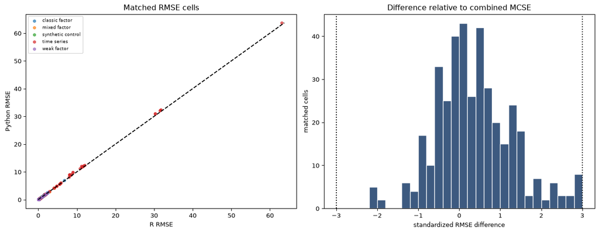

Figure 1: R and Python RMSE agreement across 398 matched simulation cells.

```python
figure, axes = plt.subplots(1, 2, figsize=(13, 5), constrained_layout=True)
families = sorted(comparison["family"].unique())
for family in families:
    selected = comparison["family"] == family
    axes[0].scatter(
        comparison.loc[selected, "r_rmse"],
        comparison.loc[selected, "python_rmse"],
        s=16,
        alpha=0.65,
        label=family.replace("_", " "),
    )
upper = float(comparison[["r_rmse", "python_rmse"]].to_numpy().max())
axes[0].plot((0.0, upper), (0.0, upper), color="black", linestyle="--")
axes[0].set_xlabel("R RMSE")
axes[0].set_ylabel("Python RMSE")
axes[0].set_title("Matched RMSE cells")
axes[0].legend(fontsize=7)

axes[1].hist(
    comparison["standardized_difference"],
    bins=np.linspace(-3.0, 3.0, 31),
    color="#3D5A80",
    edgecolor="white",
)
axes[1].axvline(-3.0, color="black", linestyle=":")
axes[1].axvline(3.0, color="black", linestyle=":")
axes[1].set_xlabel("standardized RMSE difference")
axes[1].set_ylabel("matched cells")
axes[1].set_title("Difference relative to combined MCSE")
plt.show()
```

Inspecting the tail is more useful than reporting only an average difference. It can reveal one outcome model or weighting frame that needs a separate check.

## 7 Rebuild the comparison table

The comparison script uses only the two checked-in RMSE files:

```bash
uv run python -m website.vignettes.balancing_support.compare_r_python
```

It checks that the Python grid has 398 unique keys, joins the R grid on the four design identifiers, and recomputes differences and combined Monte Carlo standard errors.

## 8 Rerun the Python Monte Carlo

The Python experiment runner is also included. It requires the optional `crabbymetrics` estimator source and can be expensive:

```bash
uv sync --extra estimators
uv run python -m website.vignettes.balancing_support.run_balancing_experiments \
  --help
```

Run it only when you intend to refresh the stored Python results. The command does not reconstruct the absent R environment.

## 9 What this check shows

The two grids cover the same 398 design and estimator cells, and their RMSE differences can be judged against Monte Carlo uncertainty. The included runner can regenerate the Python grid. The absent R project cannot be regenerated from this repository, and the comparison does not use matched random draws.